# How to keep it togetheR

Last update: 2019-01-26 09:05:23

Using list-columns - Demo for the R Cafe Universiteit Utrecht, 28 January 2019

## Who am I?

- Background in (Medical) Biology
- PhD in (Psycho)Neuroimmunology (WKZ - UMCU)
- Validation and development of in-vitro methods for toxicology (Hogeschool Utrecht)
- **SpaRked my interest in R**

## What is R to me?

- Every day go-to for analytics of very different types of data
- Statistical analysis (`{lme}`, `{lme4}`, `{nlme}`)
- Genomics (`{DESeq2}`, `{edgeR}`, `{limma}`, `{Glimma}` )
- Microbiome analysis (`Bioconductor` & `qiime2`)
- Interactivity with `{Shiny}` and `{flexdashboards}`
- Reproducibility (`{rmarkdown}`, `{bookdown}`, `{blogdown}`)
- Tutorials and teaching (`{learnr}`, `{reticulate}` (combine Python & R))
- Getting data (`{plumber}`, `{getGEO}`, `{rentrez}`)
- Text mining (`{tidytext}`, `{igraph}`, `{ggiraph}`)
- Visualizations (`{ggplot2}`, `{tidygraph}`, `{gganimate}`, `{tmap}`)

## Content for today

PART I: Starting with List-columns

**There is more than we can cover today**

PART II: MORE LIST-COLUMNS (do-it-yourself)

## Getting access and materials

Clone the repository to your RStudio Env. from:

`https://github.com/uashogeschoolutrecht/rcafe` or login

`http://rserverkcgdl.hudatascience.nl` with

login: … passwd: …

## Packages

The packages used in this tutorial

```r
library(tidyverse)
library(modelr)
library(lubridate)
library(broom)
library(purrr)
library(repurrrsive)
```

## Dataframes and lists are recursive vectors

```r
table <- tribble(
  ~ a, ~b, ~c, ~d,
  "x", 1, TRUE, 1.45,
  "y", 2, FALSE, 3.88,
  "z", 3, TRUE, 33.5
  )
table
```

```
## # A tibble: 3 x 4
##   a         b c         d
##   <chr> <dbl> <lgl> <dbl>
## 1 x         1 TRUE   1.45
## 2 y         2 FALSE  3.88
## 3 z         3 TRUE  33.5
```

```r
is.atomic(table$a)
```

```
## [1] TRUE
```

## Column containing a list (in a dataframe)

```r
table <- tribble(
  ~ a,      ~b,      ~c,       ~d,     ~e,
  "x",      1,       TRUE,     1.45,   numbers = 1:10,
  "y",      2,       FALSE,    3.88,   lgl = c(TRUE, FALSE),
  "z",      3,       TRUE,     33.5,   city = "Utrecht"
  )
is.list(table$e)
```

```
## [1] TRUE
```

## Iterate over a dataframe

```r
map(table, class)
```

```
## $a
## [1] "character"
##
## $b
## [1] "numeric"
##
## $c
## [1] "logical"
##
## $d
## [1] "numeric"
##
## $e
## [1] "list"
```

## Iterate over a list-column

```r
map(table$e, nchar)
```

```
## [[1]]
##  [1] 1 1 1 1 1 1 1 1 1 2
##
## [[2]]
## [1] 4 5
##
## [[3]]
## [1] 7
```

## Case data

Let's switch to RStudio and open the file:

`demo.Rmd`

## Data origin

Whooping cough outbreaks from The World Health Organization

http://data.euro.who.int/cisid/?TabID=463987

See for variable and data collection also:

http://ecdc.europa.eu/sites/portal/files/documents/Pertussis%20AER.pdf

for more details see file: "load_data.R"

## Load the tidy version of the dataset

The code for cleaning and tidying the data is in the file "./load_data.R"

```r
source(file = file.path(root,
                        "load_data.R"))

head(pertussis_data_tidy, n = 2)
```

```
## # A tibble: 2 x 4
##     key country year       annual_pertussis_cases
##   <dbl> <chr>   <date>                      <int>
## 1     2 Albania 1980-01-01                     NA
## 2     5 Andorra 1980-01-01                     NA
```

```r
names(pertussis_data_tidy)
```

```
## [1] "key"                    "country"
## [3] "year"                   "annual_pertussis_cases"
```

## Overall trend

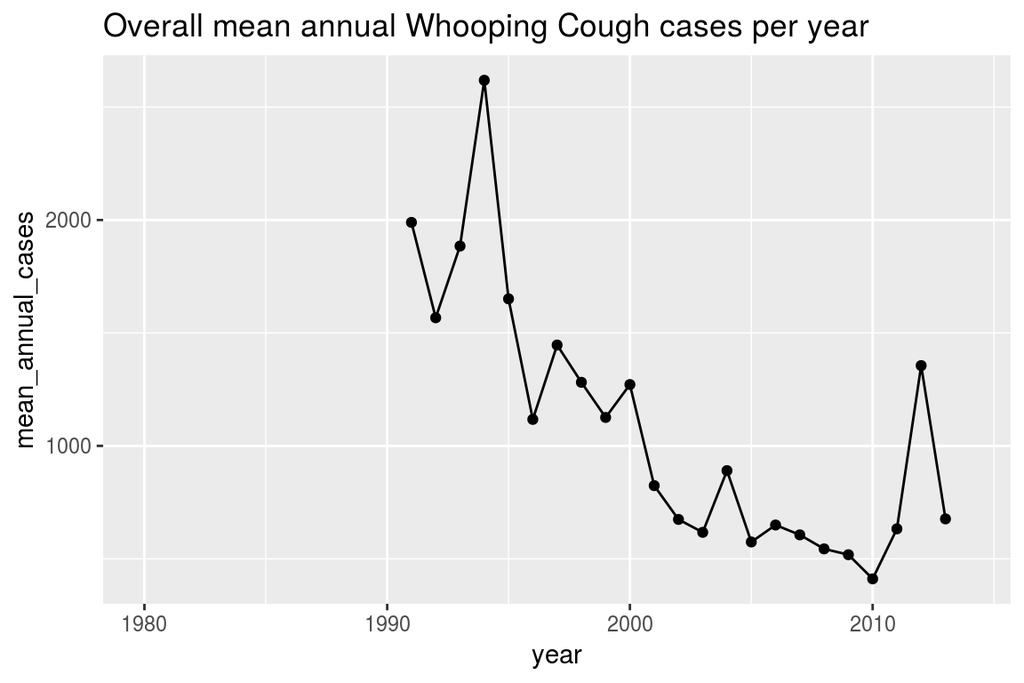

## Data for individual countries, over time

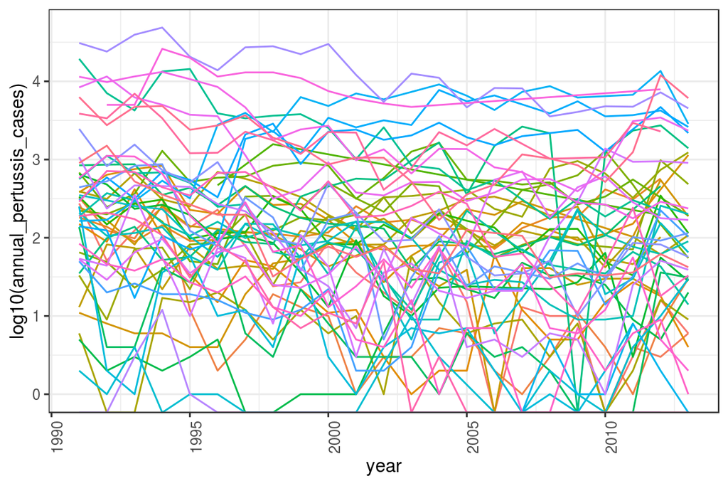

## Data for only The Netherlands

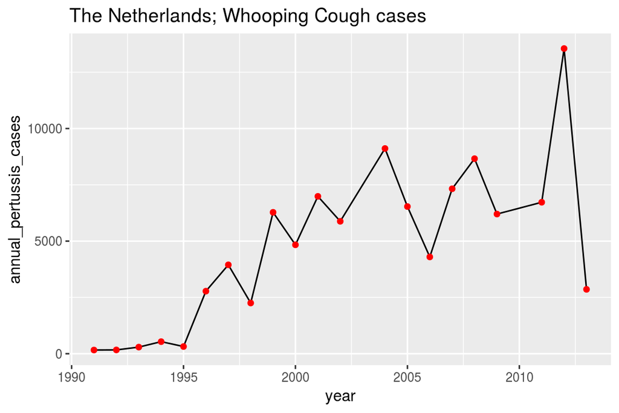

## Plot linear model for NL

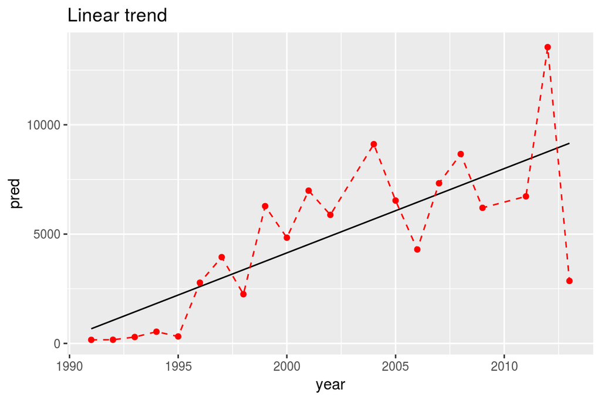

## Split the data by country and apply the model or graphing code to each subset

- In fact, data for each country is a subset of the full dataset
- We can subset the original dataframe into seperate dataframes for each country

## List-columns to track your results and models

```r
nested_pertussis <- pertussis_data_tidy %>%
  na.omit() %>%
  dplyr::select(country, year, annual_pertussis_cases) %>%
  group_by(country) %>%
    nest()
```

## Inspecting the nested dataframes

```r
head(nested_pertussis, 2) ## you see the grouping by country
```

```
## # A tibble: 2 x 2
##   country data
##   <chr>   <list>
## 1 Albania <tibble [22 × 2]>
## 2 Armenia <tibble [23 × 2]>
```

```r
head(nested_pertussis$data[[1]], 2) ## you get the individual country df
```

```
## # A tibble: 2 x 2
##   year       annual_pertussis_cases
##   <date>                      <int>
## 1 1991-01-01                    275
## 2 1992-01-01                     51
```

## Label (name) the idividual elements of the list column

```r
names(nested_pertussis$data) <- nested_pertussis$country
head(nested_pertussis$data, 1)
```

## Linear model for each country

First we write a function that creates the linear model for one country

```r
country_model_lm <- function(df){
  model <- lm(
    annual_pertussis_cases ~ year,
    data = df)
  return(model)
}
```

## Iterate the model function over nested `$data` with `purrr::map()`

```r
models <- map(
  nested_pertussis$data, country_model_lm
  )
head(models, 2)
```

```
## [[1]]
##
## Call:
## lm(formula = annual_pertussis_cases ~ year, data = df)
##
## Coefficients:
## (Intercept)         year
##   356.23325     -0.02502
##
##
## [[2]]
##
## Call:
## lm(formula = annual_pertussis_cases ~ year, data = df)
##
## Coefficients:
## (Intercept)         year
##   297.70414     -0.02168
```

## Keep it togetheR

- We have the models now
- Better to store them together with the data and the group ('country') info
- By using `dplyr::mutate()` in conjunction with `map()`

## Create an additional list-column on the basis of an existing one

```r
nested_pertussis <- nested_pertussis %>%
  mutate(models_lm = map(data, country_model_lm))
head(nested_pertussis, 2)
```

```
## # A tibble: 2 x 3
##   country data              models_lm
##   <chr>   <list>            <list>
## 1 Albania <tibble [22 × 2]> <S3: lm>
## 2 Armenia <tibble [23 × 2]> <S3: lm>
```

## Add model summaries as a list-column

```r
nested_pertussis <- nested_pertussis %>%
  mutate(models_lm_summary = map(models_lm, summary))
head(nested_pertussis, 2)
```

```
## # A tibble: 2 x 4
##   country data              models_lm models_lm_summary
##   <chr>   <list>            <list>    <list>
## 1 Albania <tibble [22 × 2]> <S3: lm>  <S3: summary.lm>
## 2 Armenia <tibble [23 × 2]> <S3: lm>  <S3: summary.lm>
```

## Extracting information from a list-column of models; `glance()` & `pluck()`

```r
nested_pertussis <- nested_pertussis %>%
  mutate(params_lm =  map(models_lm, broom::glance)) %>%
  mutate(p_value = map(params_lm, pluck, "p.value"))

nested_pertussis$params_lm[[1]]
```

```
## # A tibble: 1 x 11
##   r.squared adj.r.squared sigma statistic p.value    df logLik   AIC   BIC
##       <dbl>         <dbl> <dbl>     <dbl>   <dbl> <int>  <dbl> <dbl> <dbl>
## 1     0.529         0.505  58.8      22.4 1.27e-4     2  -120.  246.  249.
## # … with 2 more variables: deviance <dbl>, df.residual <int>
```

```r
nested_pertussis$p_value[[1]] %>% round(6)
```

```
## [1] 0.000127
```

## Adding a list of plots in a column

A function that creates a graph for a single country

```r
plot_line <- function(df, key){

  model <- lm(
  annual_pertussis_cases ~ year,
  data = df %>%
    na.omit()
)
## plot model for NL

plot <- df %>%
  na.omit() %>%
  add_predictions(model) %>%
  ggplot(aes(x = year,
             y = pred)) +
  geom_line() +
  geom_point(
    data = df,
    aes(x = year,
    y = annual_pertussis_cases),
    colour = "red") +
  geom_line(
    data = df %>% na.omit, ## note the pipe to remove NA
    aes(x = year,
        y = annual_pertussis_cases),
    colour = "red",
    linetype = "dashed"
) +
  ggtitle(paste("Linear model for", key %>% as.character()))

  return(plot)
}
```

## Iterate plot function over nested data

```r
nested_pertussis <- nested_pertussis %>%
  mutate(
    plots_lm = map2(data, country, plot_line)
  )
nested_pertussis
```

```
## # A tibble: 52 x 7
##    country   data    models_lm models_lm_summa… params_lm  p_value plots_lm
##    <chr>     <list>  <list>    <list>           <list>     <list>  <list>
##  1 Albania   <tibbl… <S3: lm>  <S3: summary.lm> <tibble [… <dbl [… <S3: gg>
##  2 Armenia   <tibbl… <S3: lm>  <S3: summary.lm> <tibble [… <dbl [… <S3: gg>
##  3 Austria   <tibbl… <S3: lm>  <S3: summary.lm> <tibble [… <dbl [… <S3: gg>
##  4 Azerbaij… <tibbl… <S3: lm>  <S3: summary.lm> <tibble [… <dbl [… <S3: gg>
##  5 Belarus   <tibbl… <S3: lm>  <S3: summary.lm> <tibble [… <dbl [… <S3: gg>
##  6 Belgium   <tibbl… <S3: lm>  <S3: summary.lm> <tibble [… <dbl [… <S3: gg>
##  7 Bosnia a… <tibbl… <S3: lm>  <S3: summary.lm> <tibble [… <dbl [… <S3: gg>
##  8 Bulgaria  <tibbl… <S3: lm>  <S3: summary.lm> <tibble [… <dbl [… <S3: gg>
##  9 Croatia   <tibbl… <S3: lm>  <S3: summary.lm> <tibble [… <dbl [… <S3: gg>
## 10 Cyprus    <tibbl… <S3: lm>  <S3: summary.lm> <tibble [… <dbl [… <S3: gg>
## # … with 42 more rows
```

## Name elements in the list-column

```r
names(nested_pertussis$plots_lm) <- nested_pertussis$country
```

## Show a plot

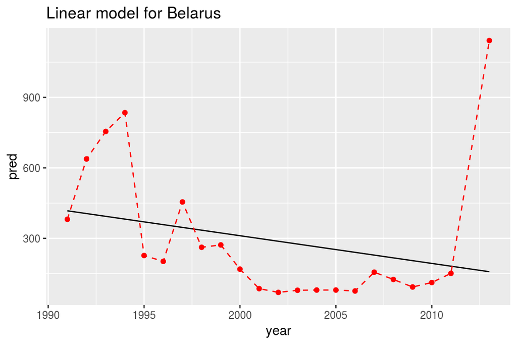

## Panel of plots

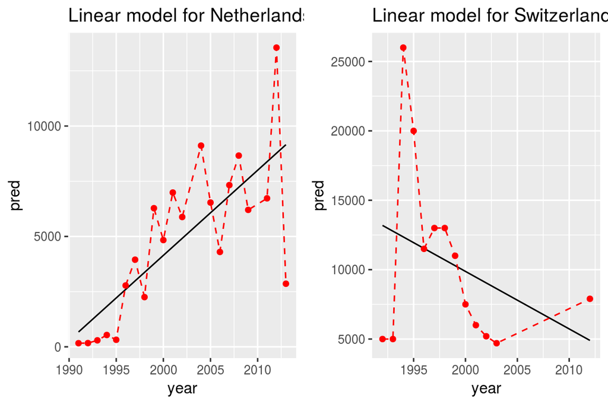

## Consider this

Imagine you are writing/using a function to loop over data or models in a list-(column) with `map()` or `lapply`, but it throws an ERROR half way through the list, stopping the loop

How would you solve this?

The answer is PART II below

## Learn more?

'Managing many models with R' by Hadley Wickham - Lecture https://www.youtube.com/watch?v=rz3_FDVt9eg

'R for Data Science' by Garret Grolemund & Hadley Wickham https://r4ds.had.co.nz/ Especially chapters: 21 - https://r4ds.had.co.nz/iteration.html 25 - https://r4ds.had.co.nz/many-models.html

[figure not shown]

## PART II; Extracting more information from a list column

**ADVANCED**

For another day…

## Looking at quantative statistical measures for model quality

```r
r_squared <- nested_pertussis %>%
  mutate(glance = map(models_lm, broom::glance)) %>%
  unnest(glance, drop = TRUE) %>%
  select(country, r.squared, AIC, BIC) %>%
  arrange(r.squared)
```

## Plotting r.sqared values

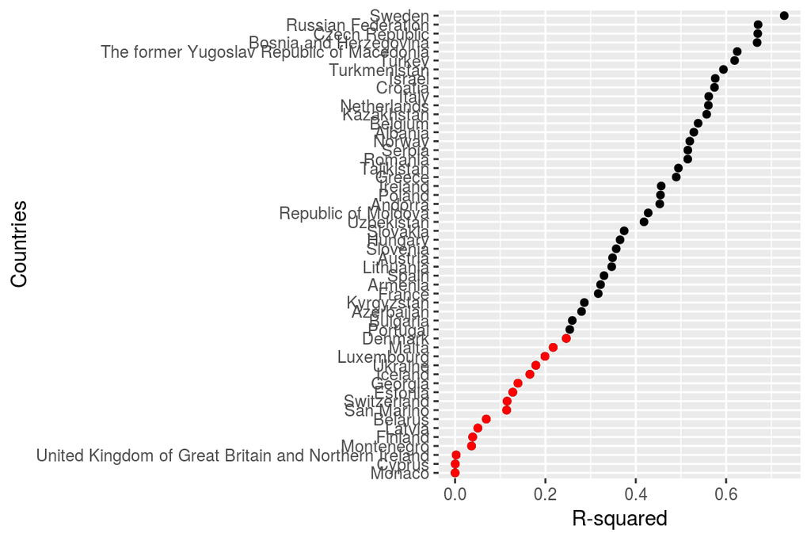

## Plotting pertussis cases for countries with low r.squared over time

1. Filter countries with `r.squared` <= 0.25
2. Put countries in vector
3. Plot data

## Step 1

```r
low_r_squared <- r_squared %>%
  dplyr::filter(r.squared <= 0.25) %>%
  dplyr::select(country)
low_r_squared <- low_r_squared$country
```

## Step 2

```r
low_r_squared_nested <- nested_pertussis %>%
  dplyr::filter(country %in% low_r_squared) %>%
  select(country, data) %>%
  unnest()
```

## Step 3

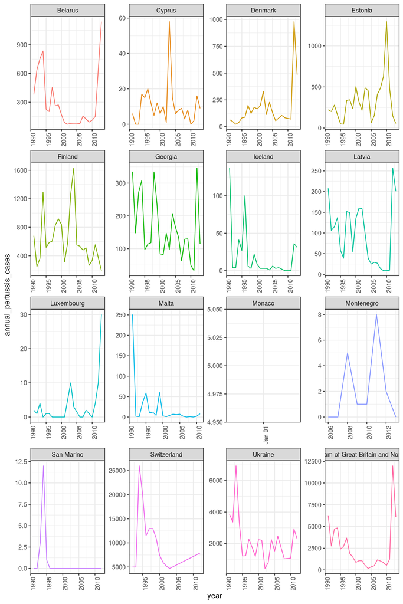

What is happening with the pertussis vaccination grade over the past 8 years?

## Store ggplot2 objects in a list-column

1. Create a function that makes the plot
2. Test function on single dataframe
3. Apply the function using `mutate()` and `map()` to all dataframes or models

```r
## isolate one dataframe to test function
df <- nested_pertussis$data[[1]]
plot_country <- function(df){

  df %>%
    ggplot(aes(x = year,
           y = annual_pertussis_cases)) +
    geom_line() +
    geom_smooth() +
    ylab("Annual cases")

}

## test function
# plot_country(df = df)
```

## Apply plotting function to nested data

```r
nested_pertussis <- nested_pertussis %>%
  mutate(plots_cases_over_time = map(data,
                                     plot_country))
```

## Add countries as names to nest-column

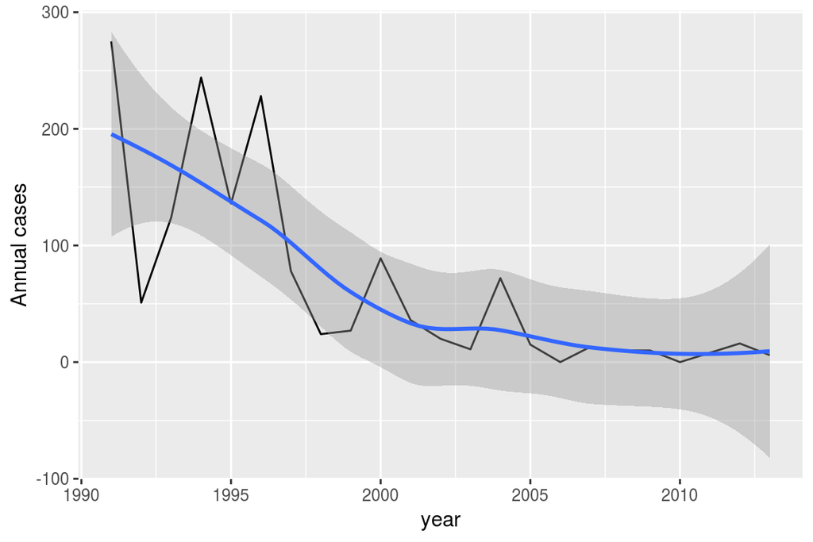

```r
names(nested_pertussis$plots_cases_over_time) <-
  c(nested_pertussis$country)

nested_pertussis$plots_cases_over_time[1]
```

## Pull out "The Netherlands"

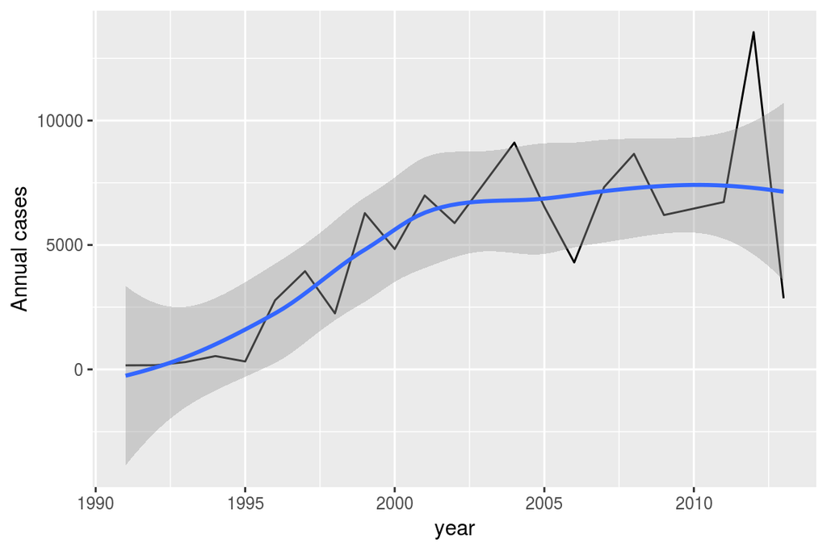

```r
nested_pertussis$plots_cases_over_time$Netherlands
```

## Plotting a panel of 4 graphs

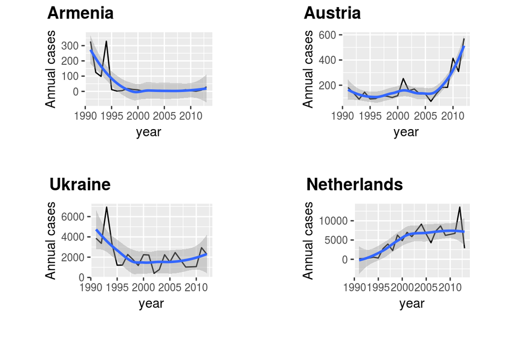

## Literature

For some background on the pattern we are seeing

- https://www.scientificamerican.com/article/why-whooping-cough-vaccines-are-wearing-off/
- http://outbreaknewstoday.com/pertussis-cases-up-significantly-in-the-eu-netherlands-and-uk-worst-hit-55315/

## Exploring many more models

Let's add a quadratic model in the mix. Assume we want to explore non-linear relationships in this dataset

```r
non_linear_model <- function(df, model_params){

  nl_model <- lm(
    annual_pertussis_cases ~ poly(year,
                                  model_params),
                 data = df)

  return(nl_model)
}
```

## Creating a safe version of this function

```r
safe_non_linear <- purrr::safely(non_linear_model)
## apply test:
df = nested_pertussis$data[[1]]

test_non_linear <-  df %>% non_linear_model(df = .,
                                            model_params = 2)
```

## Test function on one country

```r
test_non_linear %>% broom::glance()
```

```
## # A tibble: 1 x 11
##   r.squared adj.r.squared sigma statistic p.value    df logLik   AIC   BIC
##       <dbl>         <dbl> <dbl>     <dbl>   <dbl> <int>  <dbl> <dbl> <dbl>
## 1     0.607         0.566  55.0      14.7 1.39e-4     3  -118.  244.  248.
## # … with 2 more variables: deviance <dbl>, df.residual <int>
```

## Apply model to all countries

We rerun the steps above to add this new model and new graphs to the nested dataframe

Add new model to the nested table

```r
nested_pertussis <- nested_pertussis %>%
  mutate(models_nl_2 = map(data, safe_non_linear,
                          model_params = 2))

nested_pertussis$models_nl_2 <- transpose(nested_pertussis$models_nl_2)
```

## Set names to elements in the list-column

To be able to `pluck()` by name later

```r
names(nested_pertussis$models_nl_2$result) <- nested_pertussis$country
```

## Pluck results in new list-column

```r
nested_pertussis$models_nl_2$result[[1]] %>% summary
```

```
##
## Call:
## lm(formula = annual_pertussis_cases ~ poly(year, model_params),
##     data = df)
##
## Residuals:
##      Min       1Q   Median       3Q      Max
## -135.782  -19.621   -3.885    7.188  114.303
##
## Coefficients:
##                           Estimate Std. Error t value Pr(>|t|)
## (Intercept)                  67.50      11.73   5.753 1.52e-05 ***
## poly(year, model_params)1  -278.33      55.03  -5.057 7.00e-05 ***
## poly(year, model_params)2   107.53      55.03   1.954   0.0656 .
## ---
## Signif. codes:  0 '***' 0.001 '**' 0.01 '*' 0.05 '.' 0.1 ' ' 1
##
## Residual standard error: 55.03 on 19 degrees of freedom
## Multiple R-squared:  0.6074, Adjusted R-squared:  0.5661
## F-statistic:  14.7 on 2 and 19 DF,  p-value: 0.0001389
```

```r
nested_pertussis <- nested_pertussis %>%
  mutate(statistics_nl = pluck(models_nl_2, "result"))

nested_pertussis$statistics_nl[[1]] %>% summary
```

```
##
## Call:
## lm(formula = annual_pertussis_cases ~ poly(year, model_params),
##     data = df)
##
## Residuals:
##      Min       1Q   Median       3Q      Max
## -135.782  -19.621   -3.885    7.188  114.303
##
## Coefficients:
##                           Estimate Std. Error t value Pr(>|t|)
## (Intercept)                  67.50      11.73   5.753 1.52e-05 ***
## poly(year, model_params)1  -278.33      55.03  -5.057 7.00e-05 ***
## poly(year, model_params)2   107.53      55.03   1.954   0.0656 .
## ---
## Signif. codes:  0 '***' 0.001 '**' 0.01 '*' 0.05 '.' 0.1 ' ' 1
##
## Residual standard error: 55.03 on 19 degrees of freedom
## Multiple R-squared:  0.6074, Adjusted R-squared:  0.5661
## F-statistic:  14.7 on 2 and 19 DF,  p-value: 0.0001389
```

## Tidy the list-column with `{broom}`

```r
nested_pertussis <- nested_pertussis %>%
  mutate(parameters_nl = map(statistics_nl, glance))
```

## Looking at quantative statistical measures for model quality

```r
r_squared_nl <- nested_pertussis %>%
  select(country, parameters_nl) %>%
  unnest()
```

## Plotting r.sqared values

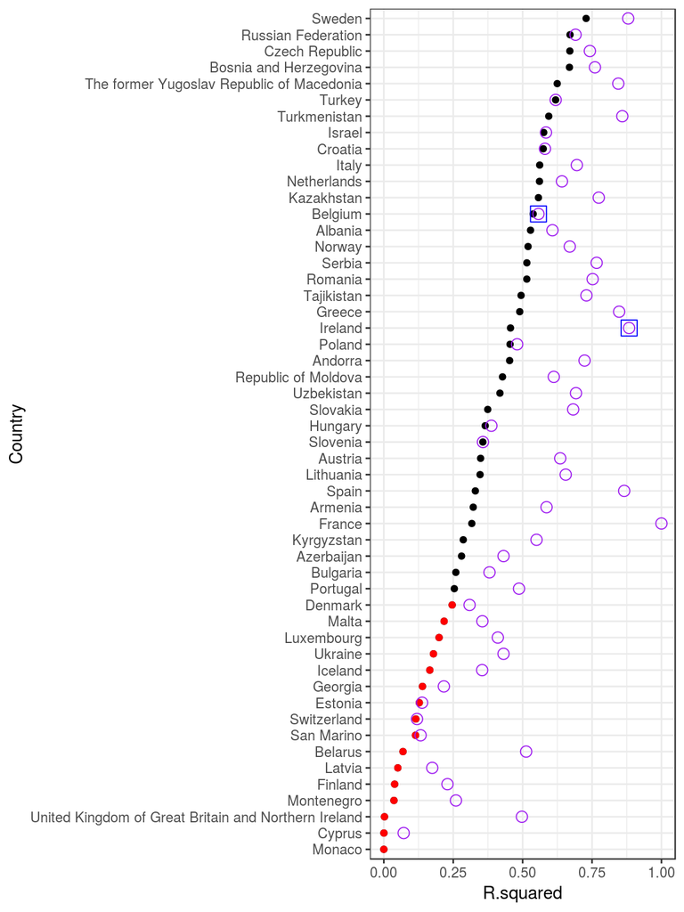

## Let's examine two models for two countries where the non-linear did and did not not improve the R.squared: Ireland (improved) and Belgium (not-improved)

```r
x <- nested_pertussis %>%
  select(country,
         data,
         models_lm,
         statistics_nl) %>%
  gather(models_lm:statistics_nl, key = "models", value = "model_params") %>%
 print()
```

```
## # A tibble: 104 x 4
##    country                data              models    model_params
##    <chr>                  <list>            <chr>     <list>
##  1 Albania                <tibble [22 × 2]> models_lm <S3: lm>
##  2 Armenia                <tibble [23 × 2]> models_lm <S3: lm>
##  3 Austria                <tibble [22 × 2]> models_lm <S3: lm>
##  4 Azerbaijan             <tibble [23 × 2]> models_lm <S3: lm>
##  5 Belarus                <tibble [22 × 2]> models_lm <S3: lm>
##  6 Belgium                <tibble [21 × 2]> models_lm <S3: lm>
##  7 Bosnia and Herzegovina <tibble [19 × 2]> models_lm <S3: lm>
##  8 Bulgaria               <tibble [22 × 2]> models_lm <S3: lm>
##  9 Croatia                <tibble [23 × 2]> models_lm <S3: lm>
## 10 Cyprus                 <tibble [23 × 2]> models_lm <S3: lm>
## # … with 94 more rows
```

## Remove 'empty model'

```r
ind <- x$model_params == "NULL"
#ind <- x$data == "NULL"
x <- x[!ind, ]
```

## Add prediction-list column

```r
predictions <- x %>%
#  filter(country == "Czech Republic") %>%
  mutate(predictions = map2(data, model_params, add_predictions,
         var = "annual_pertussis_cases")) %>%
  filter(country == "Ireland" |
         country == "Belgium") %>%
  select(country, data, predictions)
```

## Set names

```r
names(predictions$predictions) <- predictions$country
```

## Belgium

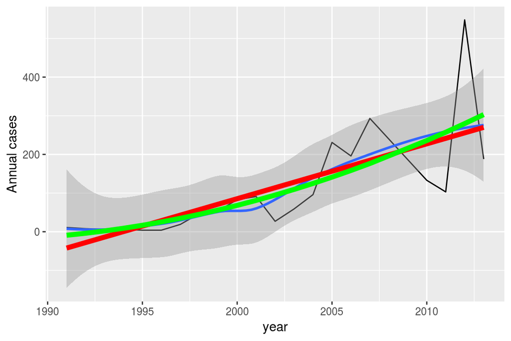

## Ireland

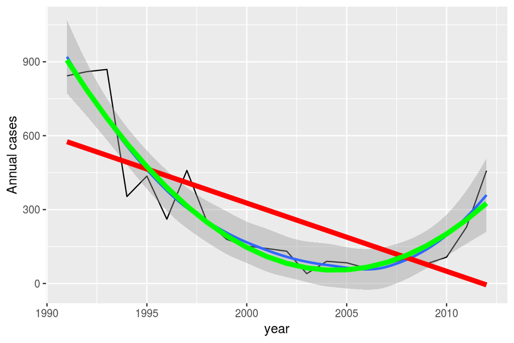

## Learn more?

To practice with more examples have a look at

```r
# repurrrsive
```

## Disclaimer & Licence

The work presented here may be shared, remixed or adapted as long as the original references and the authors of this document are mentioned in the redistribution: LICENCE: CC BY-SA

## Credits

Much of this material has been derived in one way or the other from the work of Hadley Wickham and Garret Grolemund and many others. For a more elaborate reference list see the resources.Rmd file in the project root.

Thanks to Hadley & Garret for writing the book "R for Data Science" http://r4ds.had.co.nz/ and for their work in general to innovate the R world.

Work on integration of Git/Github with R/RStudio is thoroughly and wit-fully documented by Jenny Brian. I also very much appreciate her work on the use of RMarkdown and thanks for pointing me into the direction of using the `rprojroot` package (CSAMA Course 2016). See also:

https://github.com/jennybc/happy-git-with-r & http://stat545.com/block007_first-use-rmarkdown.html